# Risk Factor Analysis

## Outcome Variable

**Outcome Variable:** pers_wasted624

## Predictor Variables

**Intervention Variable:** ever_sunderweight06

**Adjustment Set:**

- sex
- arm
- brthmon
- vagbrth
- single
- W_mage
- W_mhtcm
- W_mwtkg
- W_mbmi
- W_meducyrs
- W_feducyrs
- W_parity
- delta_brthmon
- delta_vagbrth
- delta_single
- delta_W_mage
- delta_W_mhtcm
- delta_W_mwtkg
- delta_W_mbmi
- delta_W_meducyrs
- delta_W_feducyrs
- delta_W_parity

## Stratifying Variables

The analysis was stratified on these variable(s):

- studyid
- country

## Data Summary

| studyid | country | ever_sunderweight06 | pers_wasted624 | n_cell | n | outcome_variable |
| --- | --- | --- | --- | --- | --- | --- |
| CMC-V-BCS-2002 | INDIA | 0 | 0 | 285 | 373 | pers_wasted624 |
| CMC-V-BCS-2002 | INDIA | 0 | 1 | 12 | 373 | pers_wasted624 |
| CMC-V-BCS-2002 | INDIA | 1 | 0 | 60 | 373 | pers_wasted624 |
| CMC-V-BCS-2002 | INDIA | 1 | 1 | 16 | 373 | pers_wasted624 |
| CMIN | BANGLADESH | 0 | 0 | 194 | 252 | pers_wasted624 |
| CMIN | BANGLADESH | 0 | 1 | 11 | 252 | pers_wasted624 |
| CMIN | BANGLADESH | 1 | 0 | 33 | 252 | pers_wasted624 |
| CMIN | BANGLADESH | 1 | 1 | 14 | 252 | pers_wasted624 |
| COHORTS | GUATEMALA | 0 | 0 | 904 | 1023 | pers_wasted624 |
| COHORTS | GUATEMALA | 0 | 1 | 20 | 1023 | pers_wasted624 |
| COHORTS | GUATEMALA | 1 | 0 | 78 | 1023 | pers_wasted624 |
| COHORTS | GUATEMALA | 1 | 1 | 21 | 1023 | pers_wasted624 |
| COHORTS | INDIA | 0 | 0 | 5698 | 6897 | pers_wasted624 |
| COHORTS | INDIA | 0 | 1 | 423 | 6897 | pers_wasted624 |
| COHORTS | INDIA | 1 | 0 | 428 | 6897 | pers_wasted624 |
| COHORTS | INDIA | 1 | 1 | 348 | 6897 | pers_wasted624 |
| COHORTS | PHILIPPINES | 0 | 0 | 2460 | 2809 | pers_wasted624 |
| COHORTS | PHILIPPINES | 0 | 1 | 154 | 2809 | pers_wasted624 |
| COHORTS | PHILIPPINES | 1 | 0 | 123 | 2809 | pers_wasted624 |
| COHORTS | PHILIPPINES | 1 | 1 | 72 | 2809 | pers_wasted624 |
| CONTENT | PERU | 0 | 0 | 213 | 215 | pers_wasted624 |
| CONTENT | PERU | 0 | 1 | 0 | 215 | pers_wasted624 |
| CONTENT | PERU | 1 | 0 | 2 | 215 | pers_wasted624 |
| CONTENT | PERU | 1 | 1 | 0 | 215 | pers_wasted624 |
| EE | PAKISTAN | 0 | 0 | 207 | 374 | pers_wasted624 |
| EE | PAKISTAN | 0 | 1 | 9 | 374 | pers_wasted624 |
| EE | PAKISTAN | 1 | 0 | 118 | 374 | pers_wasted624 |
| EE | PAKISTAN | 1 | 1 | 40 | 374 | pers_wasted624 |
| GMS-Nepal | NEPAL | 0 | 0 | 437 | 590 | pers_wasted624 |
| GMS-Nepal | NEPAL | 0 | 1 | 70 | 590 | pers_wasted624 |

[output cut: 90 more lines]

The following strata were considered:

- studyid: CMC-V-BCS-2002, country: INDIA
- studyid: CMIN, country: BANGLADESH
- studyid: COHORTS, country: GUATEMALA
- studyid: COHORTS, country: INDIA
- studyid: COHORTS, country: PHILIPPINES
- studyid: CONTENT, country: PERU
- studyid: EE, country: PAKISTAN
- studyid: GMS-Nepal, country: NEPAL
- studyid: Guatemala BSC, country: GUATEMALA
- studyid: IRC, country: INDIA
- studyid: JiVitA-3, country: BANGLADESH
- studyid: JiVitA-4, country: BANGLADESH
- studyid: Keneba, country: GAMBIA
- studyid: LCNI-5, country: MALAWI
- studyid: MAL-ED, country: BANGLADESH
- studyid: MAL-ED, country: BRAZIL
- studyid: MAL-ED, country: INDIA
- studyid: MAL-ED, country: NEPAL
- studyid: MAL-ED, country: PERU
- studyid: MAL-ED, country: SOUTH AFRICA
- studyid: MAL-ED, country: TANZANIA, UNITED REPUBLIC OF
- studyid: NIH-Birth, country: BANGLADESH
- studyid: NIH-Crypto, country: BANGLADESH
- studyid: PROBIT, country: BELARUS
- studyid: PROVIDE, country: BANGLADESH
- studyid: ResPak, country: PAKISTAN
- studyid: SAS-CompFeed, country: INDIA
- studyid: SAS-FoodSuppl, country: INDIA
- studyid: TanzaniaChild2, country: TANZANIA, UNITED REPUBLIC OF
- studyid: ZVITAMBO, country: ZIMBABWE

### Dropped Strata

Some strata were dropped due to rare outcomes:

- studyid: CONTENT, country: PERU
- studyid: Guatemala BSC, country: GUATEMALA
- studyid: MAL-ED, country: BANGLADESH
- studyid: MAL-ED, country: BRAZIL
- studyid: MAL-ED, country: NEPAL
- studyid: MAL-ED, country: PERU
- studyid: MAL-ED, country: SOUTH AFRICA
- studyid: MAL-ED, country: TANZANIA, UNITED REPUBLIC OF
- studyid: PROBIT, country: BELARUS

## Methods Detail

We’re interested in the causal parameters $E[Y_a]$ for all values of $a \in \mathcal{A}$. These parameters represent the mean outcome if, possibly contrary to fact, we intervened to set all units to have $A=a$. Under the randomization and positivity assumptions, these are identified by the statistical parameters $\psi_a=E_W[E_{Y|A,W}(Y|A=a,W)]$. In addition, we’re interested in the mean of $Y$, $E[Y]$ under no intervention (the observed mean). We will estimate these parameters by using SuperLearner to fit the relevant likelihood factors – $E_{Y|A,W}(Y|A=a,W)$ and $p(A=a|W)$, and then updating our likelihood fit using a joint TMLE.

For unadjusted analyses ($W=\{\}$), initial likelihoods were estimated using Lrnr_glm to estimate the simple $E(Y|A)$ and Lrnr_mean to estimate $p(A)$. For adjusted analyses, a small library containing Lrnr_glmnet, Lrnr_xgboost, and Lrnr_mean was used.

Having estimated these parameters, we will then use the delta method to estimate relative risks and attributable risks relative to a prespecified baseline level of $A$.

[output not shown]

# Results Detail

## Results Plots

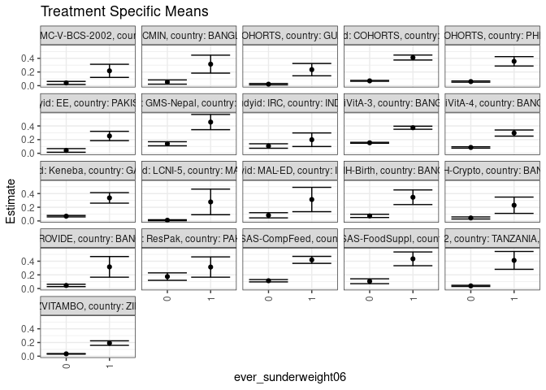

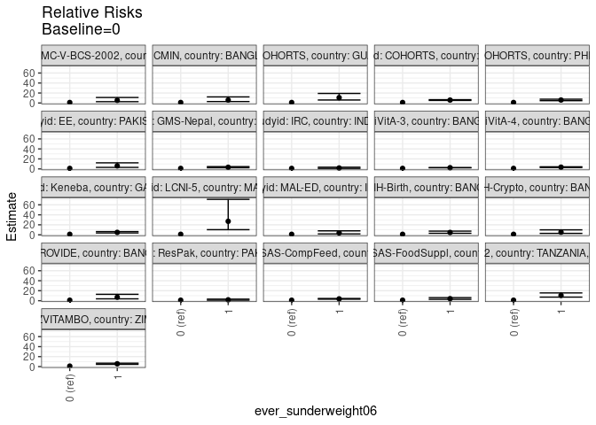

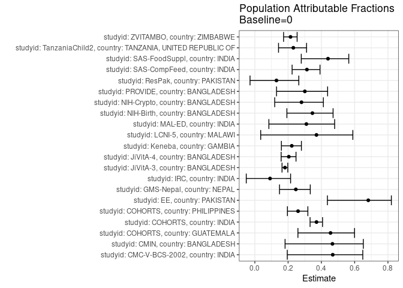

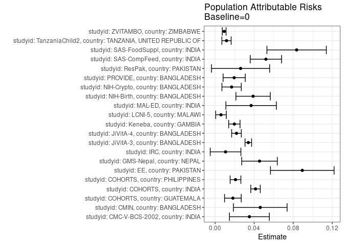

## Results Table

### Parameter: TSM

| studyid | country | intervention_level | baseline_level | estimate | ci_lower | ci_upper |
| --- | --- | --- | --- | --- | --- | --- |
| CMC-V-BCS-2002 | INDIA | 0 | NA | 0.0399125 | 0.0177319 | 0.0620931 |
| CMC-V-BCS-2002 | INDIA | 1 | NA | 0.2167831 | 0.1206623 | 0.3129040 |
| CMIN | BANGLADESH | 0 | NA | 0.0529355 | 0.0219170 | 0.0839539 |
| CMIN | BANGLADESH | 1 | NA | 0.3145440 | 0.1832928 | 0.4457951 |
| COHORTS | GUATEMALA | 0 | NA | 0.0218414 | 0.0123530 | 0.0313298 |
| COHORTS | GUATEMALA | 1 | NA | 0.2343587 | 0.1443457 | 0.3243718 |
| COHORTS | INDIA | 0 | NA | 0.0703581 | 0.0638953 | 0.0768209 |
| COHORTS | INDIA | 1 | NA | 0.4113320 | 0.3751348 | 0.4475291 |
| COHORTS | PHILIPPINES | 0 | NA | 0.0595501 | 0.0504662 | 0.0686341 |
| COHORTS | PHILIPPINES | 1 | NA | 0.3560589 | 0.2873902 | 0.4247276 |
| EE | PAKISTAN | 0 | NA | 0.0416667 | 0.0149824 | 0.0683509 |
| EE | PAKISTAN | 1 | NA | 0.2531646 | 0.1852731 | 0.3210560 |
| GMS-Nepal | NEPAL | 0 | NA | 0.1392220 | 0.1091825 | 0.1692616 |
| GMS-Nepal | NEPAL | 1 | NA | 0.4564374 | 0.3453706 | 0.5675042 |
| IRC | INDIA | 0 | NA | 0.1063671 | 0.0737071 | 0.1390271 |
| IRC | INDIA | 1 | NA | 0.1983929 | 0.0989760 | 0.2978097 |
| JiVitA-3 | BANGLADESH | 0 | NA | 0.1538870 | 0.1473814 | 0.1603926 |
| JiVitA-3 | BANGLADESH | 1 | NA | 0.3735235 | 0.3511107 | 0.3959363 |
| JiVitA-4 | BANGLADESH | 0 | NA | 0.0854441 | 0.0754894 | 0.0953988 |
| JiVitA-4 | BANGLADESH | 1 | NA | 0.2958938 | 0.2511951 | 0.3405925 |
| Keneba | GAMBIA | 0 | NA | 0.0691551 | 0.0587161 | 0.0795941 |
| Keneba | GAMBIA | 1 | NA | 0.3367175 | 0.2600499 | 0.4133851 |
| LCNI-5 | MALAWI | 0 | NA | 0.0102828 | 0.0031722 | 0.0173933 |
| LCNI-5 | MALAWI | 1 | NA | 0.2777778 | 0.0904991 | 0.4650565 |
| MAL-ED | INDIA | 0 | NA | 0.0822322 | 0.0442607 | 0.1202037 |
| MAL-ED | INDIA | 1 | NA | 0.3130975 | 0.1350297 | 0.4911653 |
| NIH-Birth | BANGLADESH | 0 | NA | 0.0735952 | 0.0496697 | 0.0975207 |
| NIH-Birth | BANGLADESH | 1 | NA | 0.3461302 | 0.2392100 | 0.4530505 |
| NIH-Crypto | BANGLADESH | 0 | NA | 0.0433733 | 0.0280305 | 0.0587161 |
| NIH-Crypto | BANGLADESH | 1 | NA | 0.2292890 | 0.1102986 | 0.3482793 |
| PROVIDE | BANGLADESH | 0 | NA | 0.0454894 | 0.0283905 | 0.0625884 |
| PROVIDE | BANGLADESH | 1 | NA | 0.3170098 | 0.1657930 | 0.4682266 |
| ResPak | PAKISTAN | 0 | NA | 0.1747446 | 0.1202585 | 0.2292306 |
| ResPak | PAKISTAN | 1 | NA | 0.3144265 | 0.1660278 | 0.4628253 |
| SAS-CompFeed | INDIA | 0 | NA | 0.1142467 | 0.0974031 | 0.1310904 |
| SAS-CompFeed | INDIA | 1 | NA | 0.4194968 | 0.3684108 | 0.4705829 |
| SAS-FoodSuppl | INDIA | 0 | NA | 0.1064383 | 0.0705677 | 0.1423089 |
| SAS-FoodSuppl | INDIA | 1 | NA | 0.4343719 | 0.3336275 | 0.5351162 |
| TanzaniaChild2 | TANZANIA, UNITED REPUBLIC OF | 0 | NA | 0.0388528 | 0.0302827 | 0.0474229 |
| TanzaniaChild2 | TANZANIA, UNITED REPUBLIC OF | 1 | NA | 0.4117096 | 0.2811433 | 0.5422758 |
| ZVITAMBO | ZIMBABWE | 0 | NA | 0.0339927 | 0.0304813 | 0.0375040 |
| ZVITAMBO | ZIMBABWE | 1 | NA | 0.1913658 | 0.1583260 | 0.2244057 |

### Parameter: E(Y)

| studyid | country | intervention_level | baseline_level | estimate | ci_lower | ci_upper |
| --- | --- | --- | --- | --- | --- | --- |
| CMC-V-BCS-2002 | INDIA | NA | NA | 0.0750670 | 0.0482904 | 0.1018437 |
| CMIN | BANGLADESH | NA | NA | 0.0992063 | 0.0622241 | 0.1361886 |
| COHORTS | GUATEMALA | NA | NA | 0.0400782 | 0.0280529 | 0.0521035 |
| COHORTS | INDIA | NA | NA | 0.1117877 | 0.1043506 | 0.1192249 |
| COHORTS | PHILIPPINES | NA | NA | 0.0804557 | 0.0703953 | 0.0905161 |
| EE | PAKISTAN | NA | NA | 0.1310160 | 0.0967738 | 0.1652583 |
| GMS-Nepal | NEPAL | NA | NA | 0.1847458 | 0.1534039 | 0.2160876 |
| IRC | INDIA | NA | NA | 0.1170732 | 0.0859146 | 0.1482317 |
| JiVitA-3 | BANGLADESH | NA | NA | 0.1879125 | 0.1813641 | 0.1944608 |
| JiVitA-4 | BANGLADESH | NA | NA | 0.1073532 | 0.0971813 | 0.1175251 |
| Keneba | GAMBIA | NA | NA | 0.0888980 | 0.0776057 | 0.1001903 |
| LCNI-5 | MALAWI | NA | NA | 0.0163317 | 0.0075211 | 0.0251422 |
| MAL-ED | INDIA | NA | NA | 0.1191489 | 0.0776405 | 0.1606574 |
| NIH-Birth | BANGLADESH | NA | NA | 0.1125461 | 0.0859151 | 0.1391771 |
| NIH-Crypto | BANGLADESH | NA | NA | 0.0602740 | 0.0429977 | 0.0775502 |
| PROVIDE | BANGLADESH | NA | NA | 0.0650407 | 0.0455353 | 0.0845460 |
| ResPak | PAKISTAN | NA | NA | 0.2008547 | 0.1494120 | 0.2522974 |
| SAS-CompFeed | INDIA | NA | NA | 0.1663067 | 0.1478935 | 0.1847199 |
| SAS-FoodSuppl | INDIA | NA | NA | 0.1900000 | 0.1515071 | 0.2284929 |
| TanzaniaChild2 | TANZANIA, UNITED REPUBLIC OF | NA | NA | 0.0505451 | 0.0409848 | 0.0601054 |
| ZVITAMBO | ZIMBABWE | NA | NA | 0.0432772 | 0.0394419 | 0.0471125 |

### Parameter: RR

| studyid | country | intervention_level | baseline_level | estimate | ci_lower | ci_upper |
| --- | --- | --- | --- | --- | --- | --- |
| CMC-V-BCS-2002 | INDIA | 0 | 0 | 1.000000 | 1.000000 | 1.000000 |
| CMC-V-BCS-2002 | INDIA | 1 | 0 | 5.431464 | 2.667252 | 11.060374 |
| CMIN | BANGLADESH | 0 | 0 | 1.000000 | 1.000000 | 1.000000 |
| CMIN | BANGLADESH | 1 | 0 | 5.942027 | 2.889280 | 12.220235 |
| COHORTS | GUATEMALA | 0 | 0 | 1.000000 | 1.000000 | 1.000000 |
| COHORTS | GUATEMALA | 1 | 0 | 10.730021 | 6.017881 | 19.131874 |
| COHORTS | INDIA | 0 | 0 | 1.000000 | 1.000000 | 1.000000 |
| COHORTS | INDIA | 1 | 0 | 5.846266 | 5.149449 | 6.637377 |
| COHORTS | PHILIPPINES | 0 | 0 | 1.000000 | 1.000000 | 1.000000 |
| COHORTS | PHILIPPINES | 1 | 0 | 5.979147 | 4.678111 | 7.642017 |
| EE | PAKISTAN | 0 | 0 | 1.000000 | 1.000000 | 1.000000 |
| EE | PAKISTAN | 1 | 0 | 6.075949 | 3.034466 | 12.165952 |
| GMS-Nepal | NEPAL | 0 | 0 | 1.000000 | 1.000000 | 1.000000 |
| GMS-Nepal | NEPAL | 1 | 0 | 3.278486 | 2.367990 | 4.539068 |
| IRC | INDIA | 0 | 0 | 1.000000 | 1.000000 | 1.000000 |
| IRC | INDIA | 1 | 0 | 1.865172 | 1.033933 | 3.364690 |
| JiVitA-3 | BANGLADESH | 0 | 0 | 1.000000 | 1.000000 | 1.000000 |
| JiVitA-3 | BANGLADESH | 1 | 0 | 2.427259 | 2.256934 | 2.610439 |
| JiVitA-4 | BANGLADESH | 0 | 0 | 1.000000 | 1.000000 | 1.000000 |
| JiVitA-4 | BANGLADESH | 1 | 0 | 3.463010 | 2.855529 | 4.199726 |
| Keneba | GAMBIA | 0 | 0 | 1.000000 | 1.000000 | 1.000000 |
| Keneba | GAMBIA | 1 | 0 | 4.869017 | 3.707101 | 6.395113 |
| LCNI-5 | MALAWI | 0 | 0 | 1.000000 | 1.000000 | 1.000000 |
| LCNI-5 | MALAWI | 1 | 0 | 27.013889 | 10.283843 | 70.960845 |
| MAL-ED | INDIA | 0 | 0 | 1.000000 | 1.000000 | 1.000000 |
| MAL-ED | INDIA | 1 | 0 | 3.807482 | 1.832418 | 7.911360 |
| NIH-Birth | BANGLADESH | 0 | 0 | 1.000000 | 1.000000 | 1.000000 |
| NIH-Birth | BANGLADESH | 1 | 0 | 4.703163 | 3.002138 | 7.367997 |
| NIH-Crypto | BANGLADESH | 0 | 0 | 1.000000 | 1.000000 | 1.000000 |
| NIH-Crypto | BANGLADESH | 1 | 0 | 5.286411 | 2.820272 | 9.909026 |
| PROVIDE | BANGLADESH | 0 | 0 | 1.000000 | 1.000000 | 1.000000 |
| PROVIDE | BANGLADESH | 1 | 0 | 6.968868 | 3.797311 | 12.789345 |
| ResPak | PAKISTAN | 0 | 0 | 1.000000 | 1.000000 | 1.000000 |
| ResPak | PAKISTAN | 1 | 0 | 1.799349 | 1.017823 | 3.180964 |
| SAS-CompFeed | INDIA | 0 | 0 | 1.000000 | 1.000000 | 1.000000 |
| SAS-CompFeed | INDIA | 1 | 0 | 3.671850 | 3.053870 | 4.414884 |
| SAS-FoodSuppl | INDIA | 0 | 0 | 1.000000 | 1.000000 | 1.000000 |
| SAS-FoodSuppl | INDIA | 1 | 0 | 4.080974 | 2.706825 | 6.152724 |
| TanzaniaChild2 | TANZANIA, UNITED REPUBLIC OF | 0 | 0 | 1.000000 | 1.000000 | 1.000000 |
| TanzaniaChild2 | TANZANIA, UNITED REPUBLIC OF | 1 | 0 | 10.596651 | 7.199746 | 15.596246 |
| ZVITAMBO | ZIMBABWE | 0 | 0 | 1.000000 | 1.000000 | 1.000000 |
| ZVITAMBO | ZIMBABWE | 1 | 0 | 5.629623 | 4.604419 | 6.883094 |

### Parameter: PAR

| studyid | country | intervention_level | baseline_level | estimate | ci_lower | ci_upper |
| --- | --- | --- | --- | --- | --- | --- |
| CMC-V-BCS-2002 | INDIA | 0 | NA | 0.0351546 | 0.0147076 | 0.0556015 |
| CMIN | BANGLADESH | 0 | NA | 0.0462709 | 0.0187664 | 0.0737753 |
| COHORTS | GUATEMALA | 0 | NA | 0.0182368 | 0.0096792 | 0.0267944 |
| COHORTS | INDIA | 0 | NA | 0.0414297 | 0.0365555 | 0.0463038 |
| COHORTS | PHILIPPINES | 0 | NA | 0.0209056 | 0.0154041 | 0.0264070 |
| EE | PAKISTAN | 0 | NA | 0.0893494 | 0.0567594 | 0.1219393 |
| GMS-Nepal | NEPAL | 0 | NA | 0.0455238 | 0.0272938 | 0.0637537 |
| IRC | INDIA | 0 | NA | 0.0107061 | -0.0050218 | 0.0264340 |
| JiVitA-3 | BANGLADESH | 0 | NA | 0.0340255 | 0.0306548 | 0.0373962 |
| JiVitA-4 | BANGLADESH | 0 | NA | 0.0219091 | 0.0169541 | 0.0268642 |
| Keneba | GAMBIA | 0 | NA | 0.0197429 | 0.0139204 | 0.0255653 |
| LCNI-5 | MALAWI | 0 | NA | 0.0060489 | 0.0006088 | 0.0114889 |
| MAL-ED | INDIA | 0 | NA | 0.0369168 | 0.0110521 | 0.0627814 |
| NIH-Birth | BANGLADESH | 0 | NA | 0.0389509 | 0.0213312 | 0.0565707 |
| NIH-Crypto | BANGLADESH | 0 | NA | 0.0169007 | 0.0069747 | 0.0268267 |
| PROVIDE | BANGLADESH | 0 | NA | 0.0195512 | 0.0081898 | 0.0309126 |
| ResPak | PAKISTAN | 0 | NA | 0.0261101 | -0.0036795 | 0.0558998 |
| SAS-CompFeed | INDIA | 0 | NA | 0.0520600 | 0.0359849 | 0.0681350 |
| SAS-FoodSuppl | INDIA | 0 | NA | 0.0835617 | 0.0531188 | 0.1140046 |
| TanzaniaChild2 | TANZANIA, UNITED REPUBLIC OF | 0 | NA | 0.0116923 | 0.0069453 | 0.0164393 |
| ZVITAMBO | ZIMBABWE | 0 | NA | 0.0092846 | 0.0073510 | 0.0112181 |

### Parameter: PAF

| studyid | country | intervention_level | baseline_level | estimate | ci_lower | ci_upper |
| --- | --- | --- | --- | --- | --- | --- |
| CMC-V-BCS-2002 | INDIA | 0 | NA | 0.4683089 | 0.1949417 | 0.6488510 |
| CMIN | BANGLADESH | 0 | NA | 0.4664105 | 0.1818108 | 0.6520148 |
| COHORTS | GUATEMALA | 0 | NA | 0.4550303 | 0.2590617 | 0.5991678 |
| COHORTS | INDIA | 0 | NA | 0.3706102 | 0.3320188 | 0.4069721 |
| COHORTS | PHILIPPINES | 0 | NA | 0.2598394 | 0.1958555 | 0.3187323 |
| EE | PAKISTAN | 0 | NA | 0.6819728 | 0.4362210 | 0.8206012 |
| GMS-Nepal | NEPAL | 0 | NA | 0.2464130 | 0.1482914 | 0.3332304 |
| IRC | INDIA | 0 | NA | 0.0914478 | -0.0515189 | 0.2149765 |
| JiVitA-3 | BANGLADESH | 0 | NA | 0.1810711 | 0.1635530 | 0.1982223 |
| JiVitA-4 | BANGLADESH | 0 | NA | 0.2040843 | 0.1581753 | 0.2474896 |
| Keneba | GAMBIA | 0 | NA | 0.2220844 | 0.1596040 | 0.2799197 |
| LCNI-5 | MALAWI | 0 | NA | 0.3703777 | 0.0352375 | 0.5890965 |
| MAL-ED | INDIA | 0 | NA | 0.3098371 | 0.0844559 | 0.4797357 |
| NIH-Birth | BANGLADESH | 0 | NA | 0.3460885 | 0.1926598 | 0.4703593 |
| NIH-Crypto | BANGLADESH | 0 | NA | 0.2803979 | 0.1194100 | 0.4119542 |
| PROVIDE | BANGLADESH | 0 | NA | 0.3006001 | 0.1303907 | 0.4374943 |
| ResPak | PAKISTAN | 0 | NA | 0.1299952 | -0.0288444 | 0.2643120 |
| SAS-CompFeed | INDIA | 0 | NA | 0.3130358 | 0.2241074 | 0.3917718 |
| SAS-FoodSuppl | INDIA | 0 | NA | 0.4397985 | 0.2791755 | 0.5646295 |
| TanzaniaChild2 | TANZANIA, UNITED REPUBLIC OF | 0 | NA | 0.2313240 | 0.1424776 | 0.3109652 |
| ZVITAMBO | ZIMBABWE | 0 | NA | 0.2145372 | 0.1727602 | 0.2542045 |